# PML Project

Joseph I

October 21, 2014

## Executive Summary

Using devices such as Jawbone Up, Nike FuelBand, and Fitbit it is now possible to collect a large amount of data about personal activity relatively inexpensively. These type of devices are part of the quantified self movement – a group of enthusiasts who take measurements about themselves regularly to improve their health, to find patterns in their behavior, or because they are tech geeks. One thing that people regularly do is quantify how much of a particular activity they do, but they rarely quantify how well they do it. In this project, I will be using data from accelerometers on the belt, forearm, arm, and dumbell of 6 participants. They were asked to perform barbell lifts correctly and incorrectly in 5 different ways, and use machine learning techniques to predict the ways participants had conducted their exercises.

The five different ways are * Class A - exactly according to the specification * Class B - throwing the elbows to the front * Class C - lifting the dumbbell only halfway * Class D - lowering the dumbbell only halfway * Class E - throwing the hips to the front

The predicting model used is random forest, and data are divided into 70/30 for training and testing. K-Fold of 10 is employed during training, and I have also removed feature sets that contain NA or empty value, and timestamp features. The result is accurate enough that I did not attempt to impute values on NA or emptye string features.

## Downlaod training and test files for modeling.

```r
library(caret)
```

```r
library(ggplot2)
library(doSNOW)
if (!file.exists("training.raw.csv")) {
  download.file("https://d396qusza40orc.cloudfront.net/predmachlearn/pml-training.csv", method="curl", dest="training.raw.csv")
}
if (!file.exists("testing.raw.csv")) {
  download.file("https://d396qusza40orc.cloudfront.net/predmachlearn/pml-testing.csv", method="curl", dest="testing.raw.csv")
}
testing.raw <- read.table("testing.raw.csv", header=TRUE, sep=",")
training.raw <- read.table("training.raw.csv", header=TRUE, sep=",")
```

## Exploratory analysis on the training data

```r
dim(testing.raw)
```

```
## [1]  20 160
```

```r
dim(training.raw)
```

```
## [1] 19622   160
```

```r
range = 1:5 # features to skip: username and timestamp

# sample columns with lots of NA and emptys
# use colMeans and colSums to identify them, less than 5% is NA, and less than 10 empty
# also skip X and username, X (possibly row number) is heavy indicator because results are sorted
# also skip new_windows and num_windows
training.data <- subset(training.raw, select=colSums(training.raw == "", na.rm=TRUE) < 10 & colMeans(is.na(training.raw)) < 0.05)[,-range]
testing.data <- subset(testing.raw, select=colSums(testing.raw == "", na.rm=TRUE) < 10 & colMeans(is.na(testing.raw)) < 0.05)[,-range]
```

## Create Partition for Training and Validating

```r
set.seed(825)
trainIndex = createDataPartition(training.data$classe, p = 0.70,list=FALSE)
training <- training.data[trainIndex,]
validating <- training.data[-trainIndex,]
```

## Training model using Random Forest, and cross validation

```r
system.time(fitModel <- train(classe ~ ., data = training[sample(nrow(training)),], method = "rf", importance=TRUE, trControl = trainControl(method = "cv", number = 10)))
```

```
##     user   system  elapsed
##  135.224    1.078 1325.727
```

[output not shown]

## Examine Model and Variables

```r
print(fitModel$finalModel)
```

```
##
## Call:
##  randomForest(x = x, y = y, mtry = param$mtry, importance = TRUE)
##                Type of random forest: classification
##                      Number of trees: 500
## No. of variables tried at each split: 28
##
##         OOB estimate of  error rate: 0.17%
## Confusion matrix:
##      A    B    C    D    E class.error
## A 3905    1    0    0    0   0.0002560
## B    4 2651    3    0    0   0.0026336
## C    0    2 2394    0    0   0.0008347
## D    0    0    9 2243    0   0.0039964
## E    0    1    0    3 2521   0.0015842
```

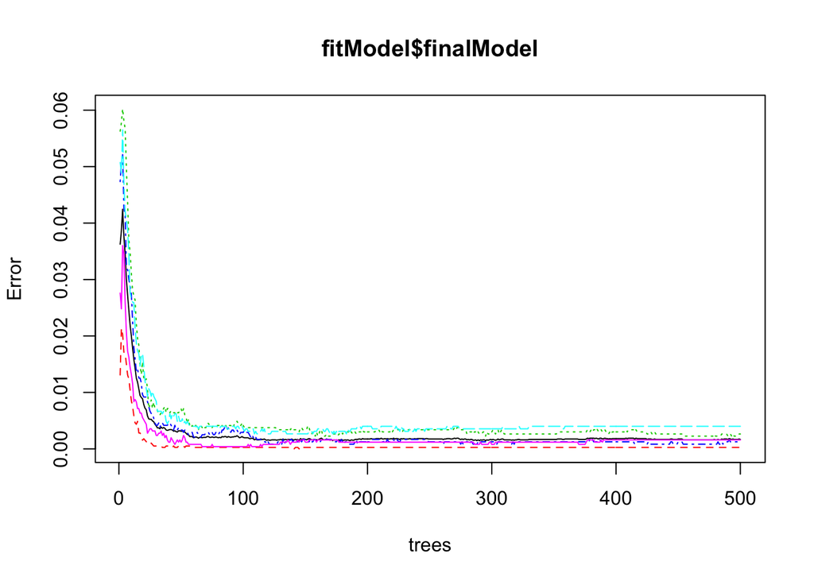

```r
plot(fitModel$finalModel)
```

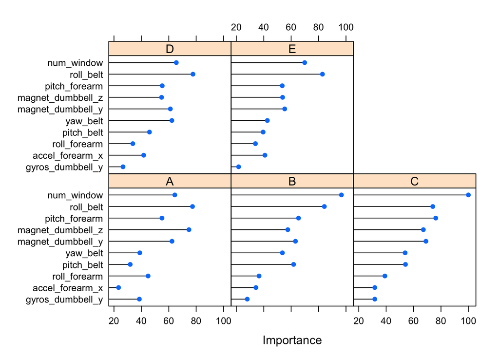

```r
plot(varImp(fitModel), top=10)
```

From the result, we observe an in-sample error of 0.17%, from varImp plot, the most critical variables are “num_window” and “roll_belt”. I estimate out-sample error to be higher than in-sample error, but should be very similar because a high k-fold sampling should address a lot of overfitting concern.

## Validation on allocated samples

```r
randomValidating <- validating[sample(nrow(validating)),]
p <- predict(fitModel, newdata=randomValidating)
confusionMatrix(p,randomValidating$classe)
```

```
## Confusion Matrix and Statistics
##
##           Reference
## Prediction    A    B    C    D    E
##          A 1673    2    0    0    0
##          B    0 1135    3    0    0
##          C    0    1 1023    8    0
##          D    0    1    0  955    2
##          E    1    0    0    1 1080
##
## Overall Statistics
##
##                Accuracy : 0.997
##                  95% CI : (0.995, 0.998)
##     No Information Rate : 0.284
##     P-Value [Acc > NIR] : <2e-16
##
##                   Kappa : 0.996
##  Mcnemar's Test P-Value : NA
##
## Statistics by Class:
##
##                      Class: A Class: B Class: C Class: D Class: E
## Sensitivity             0.999    0.996    0.997    0.991    0.998
## Specificity             1.000    0.999    0.998    0.999    1.000
## Pos Pred Value          0.999    0.997    0.991    0.997    0.998
## Neg Pred Value          1.000    0.999    0.999    0.998    1.000
## Prevalence              0.284    0.194    0.174    0.164    0.184
## Detection Rate          0.284    0.193    0.174    0.162    0.184
## Detection Prevalence    0.285    0.193    0.175    0.163    0.184
## Balanced Accuracy       0.999    0.998    0.998    0.995    0.999
```

Predict the result on our validation sample shows an out-sample error of 0.32%.

## Reference

Velloso, E.; Bulling, A.; Gellersen, H.; Ugulino, W.; Fuks, H. Qualitative Activity Recognition of Weight Lifting Exercises. Proceedings of 4th International Conference in Cooperation with SIGCHI (Augmented Human ’13) . Stuttgart, Germany: ACM SIGCHI, 2013.

Read more: http://groupware.les.inf.puc-rio.br/har#ixzz3HCw8qVYo